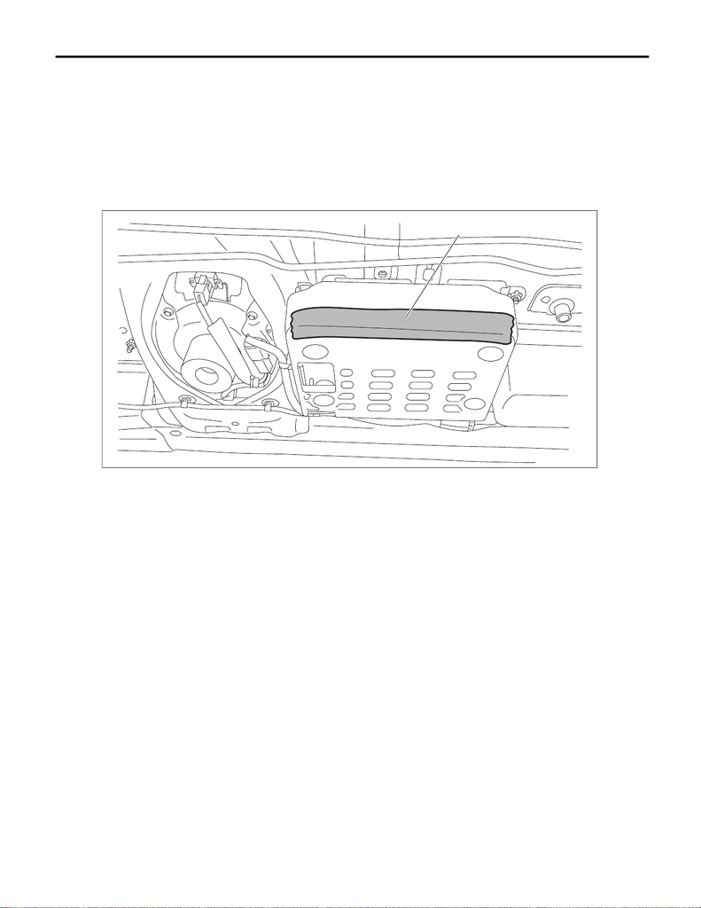

EB-51

Trunk Lid

EXTERIOR BODY PANELS

9. Trunk Lid

A: REMOVAL

1. TORSION BAR

CAUTION:

Trunk lid COMPL is heavy. When removing and installing it, always work in a team of two or more per-

sons.

1) Remove the trunk room trim. <Ref. to EI-95, REMOVAL, Trunk Room Trim.>

2) Attach the protective tape (a) to the amplifier case. (Only for models with power amplifier)

EB-00981

(a)

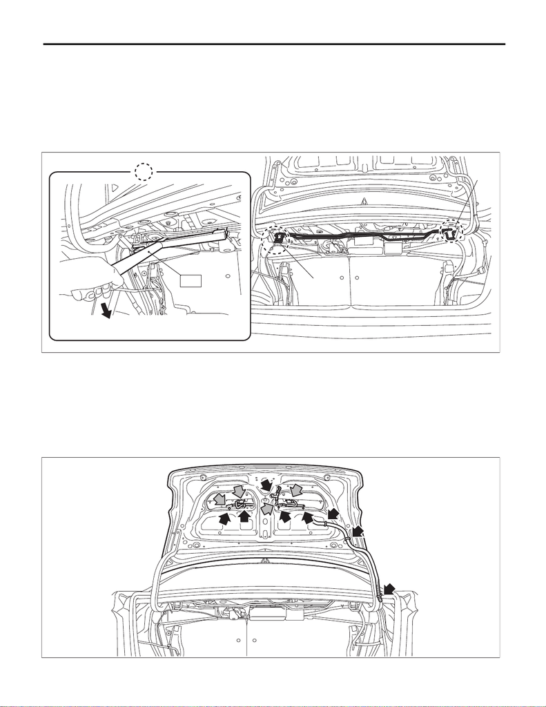

EB-52

Trunk Lid

EXTERIOR BODY PANELS

3) Remove the torsion bar - trunk lid.

CAUTION:

During removal and installation, handle the torsion bar - trunk lid carefully, because it will generate

reactive force.

Preparation tool:

ST: REMOVER (99099FJ000)

(1) Remove the torsion bar - trunk lid on the LH side from the hinge link (a).

(2) Remove the torsion bar - trunk lid on the RH side from the hinge link (b).

2. TRUNK LID PANEL

1) Disconnect the ground cable from battery. <Ref. to NT-5, BATTERY, NOTE, Note.>

NOTE:

For models other than STI model, disconnect the ground terminal from battery sensor.

2) Remove the trunk room trim. <Ref. to EI-95, REMOVAL, Trunk Room Trim.>

3) Remove the lock assembly - trunk lid. <Ref. to SL-49, REMOVAL, Trunk Lid Latch and Actuator Assem-

bly.>

4) Disconnect the connector to remove the trunk lid harness.

EB-00977

(a)

(b)

ST

EB-00984

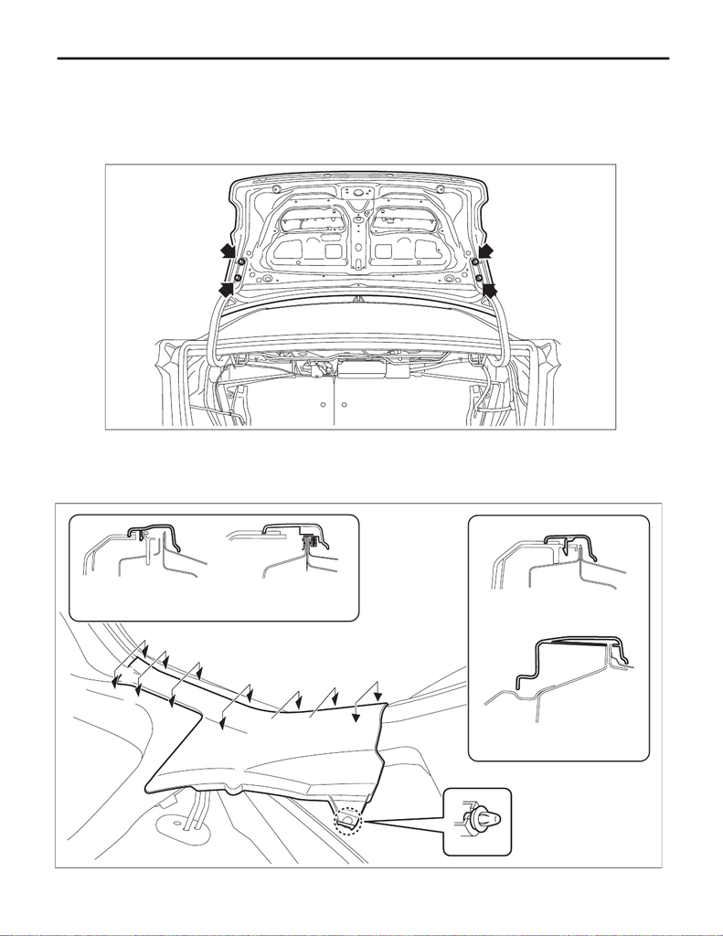

EB-53

Trunk Lid

EXTERIOR BODY PANELS

5) Remove the garnish - trunk. <Ref. to EI-51, REMOVAL, Trunk Lid Garnish.>

6) Detach the rear spoiler. <Ref. to EI-52, REMOVAL, Rear Spoiler.>

7) Remove the trunk lid COMPL.

CAUTION:

Trunk lid COMPL is heavy. When removing and installing it, always work in a team of two or more per-

sons.

8) Remove the rear seat cushion assembly. <Ref. to SE-29, REMOVAL, Rear Seat.>

9) Release the clips and claws, and remove the side sill covers - rear INN on the left and right sides.

CAUTION:

Do not pull with excessive force. Doing so may damage the claws of the side sill cover - rear INN.

EB-00978

EI-03497

A

A

B

B

C-C

D-D

D

D

C

C

C

C

B

B

A-A

B-B

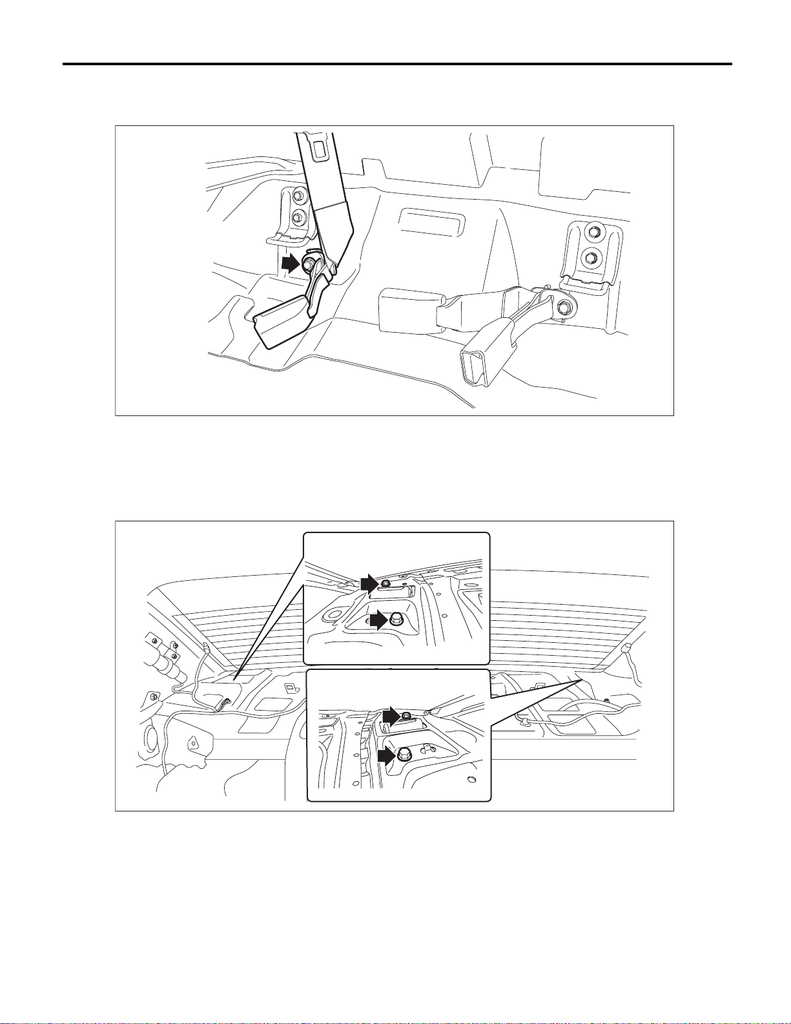

EB-54

Trunk Lid

EXTERIOR BODY PANELS

10) Remove the trim panel - rear pillar UPR and trim panel - rear pillar LWR on the RH and LH sides. <Ref.

to EI-89, REMOVAL, Rear Quarter Trim.>

11) Remove the bolts, and remove the lower anchor of the seat belt - rear shoulder CTR.

12) Remove the high-mounted stop light. <Ref. to LI-58, REMOVAL, High-mounted Stop Light.>

13) Remove the trim panel assembly - rear shelf. <Ref. to EI-92, REMOVAL, Rear Shelf Trim.>

14) Remove the trunk lid arm assembly.

(1) Remove the torsion bar - trunk lid from the trunk lid arm. <Ref. to EB-51, TORSION BAR, REMOVAL,

Trunk Lid.>

(2) Remove the bolts, then remove the trunk lid arm assembly.

EI-03459

EB-00982

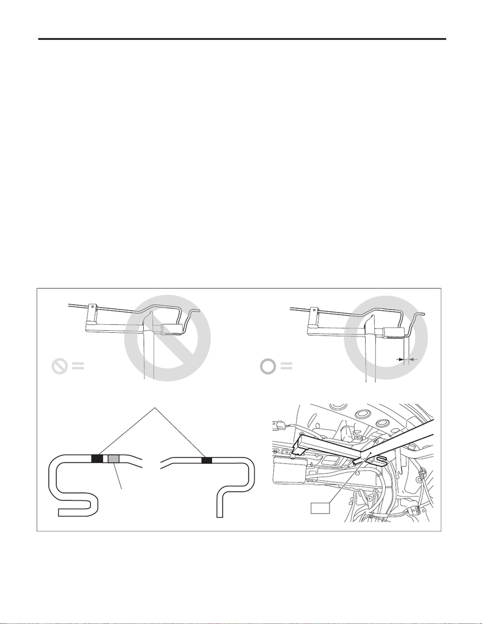

EB-55

Trunk Lid

EXTERIOR BODY PANELS

B: INSTALLATION

1) Install the trunk lid arm assembly.

Tightening torque

18 N·m (1.8 kgf-m, 13.3 ft-lb)

2) Install the trim panel assembly - rear shelf.

3) Install the high-mounted stop light.

CAUTION:

Make sure that the claw behind the light assembly - high-mounted is securely attached to the trim

panel assembly - rear shelf.

4) Install the lower anchor of seat belt - rear shoulder CTR.

Tightening torque:

30 N·m (3.1 kgf-m, 22.1 ft-lb)

5) Install the trim panel - rear pillar UPR and the trim panel - rear pillar LWR.

6) Install the side sill cover - rear INN.

7) Install the rear seat cushion assembly.

8) Install the torsion bar - trunk lid.

CAUTION:

• When performing installation, pay close attention to the identification marks and shapes of the tor-

sion bar - trunk lid on the RH and LH sides.

• When installing the remover to the torsion bar - trunk lid, leave a slight clearance (c).

Preparation tool:

ST: REMOVER (99099FJ000)

(A) Left Hand (B) Right Hand

(a) Common marking on the right and

left sides

(b) Marking on the left side only (c) Clearance

EB-00971

N

G

=

OK

=

(A) (B)

(a)

(c)

(b)

ST

[figure not shown]

EB-56

Trunk Lid

EXTERIOR BODY PANELS

9) Install the trunk lid COMPL.

Tightening torque

14 N·m (1.4 kgf-m, 10.3 ft-lb)

10) Install the rear spoiler.

Tightening torque

7.5 N·m (0.8 kgf-m, 5.5 ft-lb)

11) Install the garnish - trunk.

Tightening torque

4.5 N·m (0.5 kgf-m, 3.3 ft-lb)

12) Install the latch and actuator - trunk lid.

Tightening torque

7.5 N·m (0.8 kgf-m, 5.5 ft-lb)

13) Install the trunk lid harness.

14) Install the lock assembly - trunk lid.

15) Apply grease to the rotating area of hinges.

16) Install while paying attention to make a uniform clearance around the trunk lid COMPL. <Ref. to EB-56,

ADJUSTMENT, Trunk Lid.>

Tightening torque:

Refer to “COMPONENT” of “General Description”. <Ref. to EB-6, TRUNK LID PANEL, COMPO-

NENT, General Description.>

17) Connect the battery ground terminal. <Ref. to NT-5, BATTERY, NOTE, Note.>

NOTE:

For models other than STI model, connect the ground terminal to battery sensor.

C: ADJUSTMENT

Adjust the clearance around the trunk lid COMPL as follows.

Part Standard

A Trunk lid COMPL and Panel - side outer 3.5±1.0 mm (0.14±0.04 in)

B Surface level gap between Trunk lid COMPL and Panel -

side outer

–0.5+1.0, –0.5 mm (–0.02+0.04, –0.02 in)

C Trunk lid COMPL and Panel - side outer 3.5±1.0 mm (0.14±0.04 in)

D Surface level gap between Trunk lid COMPL and Panel -

side outer

–0.5±0.7 mm (0.02±0.03 in)

E Trunk lid COMPL to Bumper face - rear 7.5±1.0 mm (0.3±0.04 in)

EB-00979

E

A

B

C

D

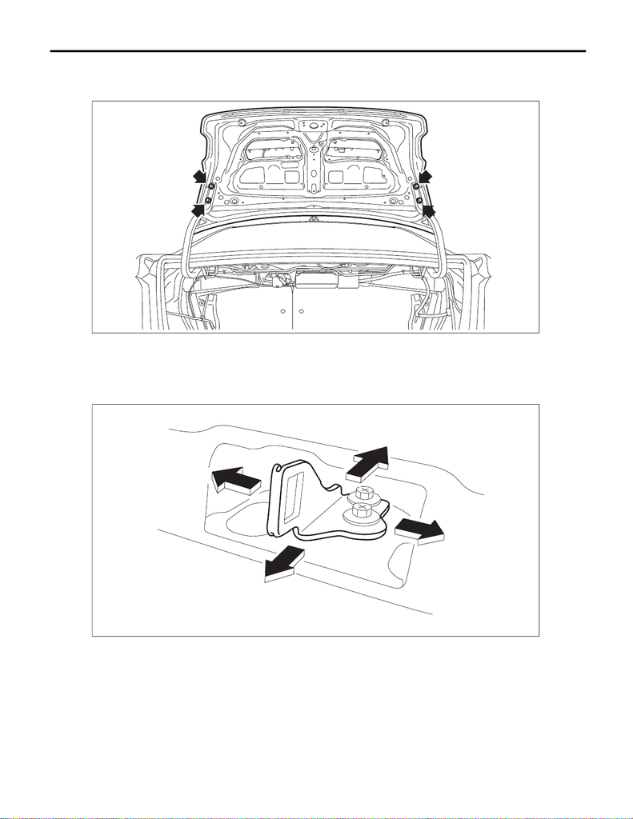

EB-57

Trunk Lid

EXTERIOR BODY PANELS

1) Adjust the horizontal position of the trunk lid COMPL.

(1) Loosen the mounting bolt.

(2) Adjust the horizontal clearance of the trunk lid COMPL.

2) Adjust the surface level gap between the trunk lid COMPL and the body.

(1) Remove the trim panel - trunk rear.

(2) Loosen the bolt.

(3) Tap the striker - trunk using a plastic hammer to adjust the surface level gap between the trunk lid

COMPL and the body.

EB-00978

EB-00705